# BIOL606_hw_Lecture14_Fahey

Sean Fahey

2023-04-10

```r
library(ggplot2)
library(factoextra)
library(ggfortify)
```

# In Class Work

Doing PCA analysis on the USairpollution dataset.

### Import and inspect data

```r
air = read.csv("USairpollution.csv", header=TRUE)
pg = read.csv("pgfull.txt", header=TRUE, sep="\t")
```

```r
head(air)
```

```
##   SO2 manu popul wind precip predays negtemp  Region        City
## 1  46   44   116  8.8  33.36     135   -47.6    East      Albany
## 2  11   46   244  8.9   7.77      58   -56.8    West Albuquerque
## 3  24  368   497  9.1  48.34     115   -61.5   South     Atlanta
## 4  47  625   905  9.6  41.31     111   -55.0    East   Baltimore
## 5  11  391   463 12.4  36.11     166   -47.1 Midwest     Buffalo
## 6  31   35    71  6.5  40.75     148   -55.2   South  Charleston
```

Trying to understand what correlates with increased SO2 concentration.

We could use all of these as predictors. But some of these might be correlated. Let’s check.

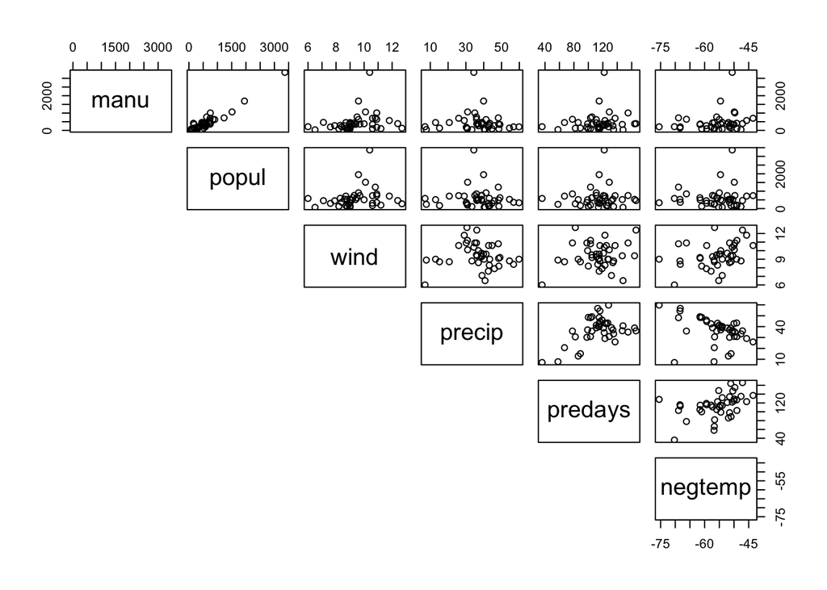

```r
# exclude columns 1, 8, and 9
pairs(air[,c(-1,-8,-9)], lower.panel = NULL)
```

```r
?pairs
```

Manu and popul are pretty correlated. Also precip/predays and precip/negtemp are pretty correlated.

### PCA

```r
air.pca = prcomp(air[,c(-1,-8,-9)], center=TRUE, scale=TRUE)
summary(air.pca)
```

```
## Importance of components:
##                          PC1   PC2    PC3    PC4    PC5     PC6
## Standard deviation     1.482 1.225 1.1810 0.8719 0.3385 0.18560
## Proportion of Variance 0.366 0.250 0.2324 0.1267 0.0191 0.00574
## Cumulative Proportion  0.366 0.616 0.8485 0.9752 0.9943 1.00000
```

PC1 explains 36.6% of the variation. But each subsequent value explains less and less. The first 3 principal components explain ~85% of the variation.

PC1, PC2, and PC3 could be used new variables in a regression to make an easier model that would still be pretty good.

Here’s a way to plot the amount of variance contained in each component.

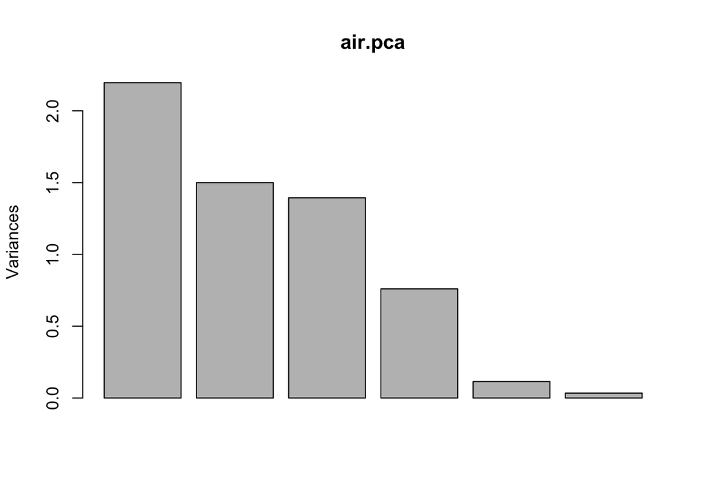

```r
screeplot(air.pca)
```

```r
air.pca
```

```
## Standard deviations (1, .., p=6):
## [1] 1.4819456 1.2247218 1.1809526 0.8719099 0.3384829 0.1855998
##
## Rotation (n x k) = (6 x 6):
##                 PC1        PC2         PC3         PC4         PC5         PC6
## manu     0.61154243 -0.1680577 -0.27288633  0.13684076  0.10204211 -0.70297051
## popul    0.57782195 -0.2224533 -0.35037413  0.07248126 -0.07806551  0.69464131
## wind     0.35383877  0.1307915  0.29725334 -0.86942583 -0.11326688 -0.02452501
## precip  -0.04080701  0.6228578 -0.50456294 -0.17114826  0.56818342  0.06062222
## predays  0.23791593  0.7077653  0.09308852  0.31130693 -0.58000387 -0.02196062
## negtemp  0.32964613  0.1275974  0.67168611  0.30645728  0.55805638  0.13618780
```

We can see which variables are most important for each principal component. For example: PC3 is made up mostly of negtemp, precip, and popul, with a bit of manu and wind, and very little input from predays.

How is PC3 calculated then??

> PC3 = -0.27288633(manu) - 0.35037413(popul) + 0.29725334(wind) - 0.50456294(precip) + 0.09308852(predays) + 0.67168611(negtemp)

### Plotting/visualization

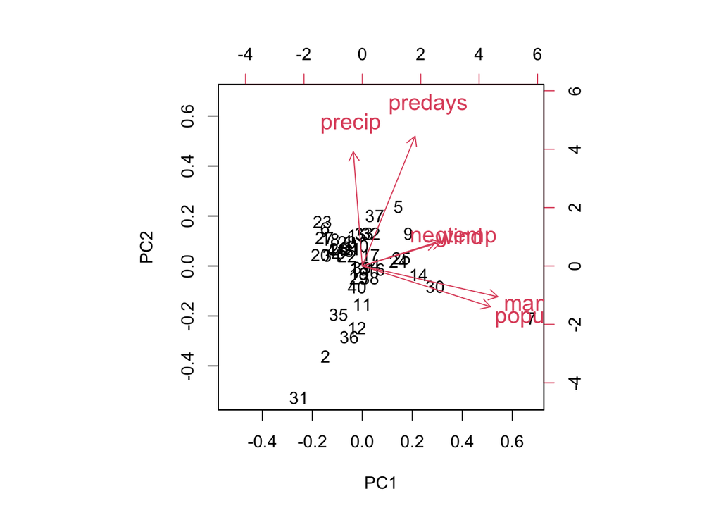

```r
biplot(air.pca, cex = c(1, 1.3), xlab = "PC1", ylab = "PC2")
```

Hard to see. But shows relative variation present for each variable. Things more important for PC1 show arrows running further along the x axis, PC2 on y axis.

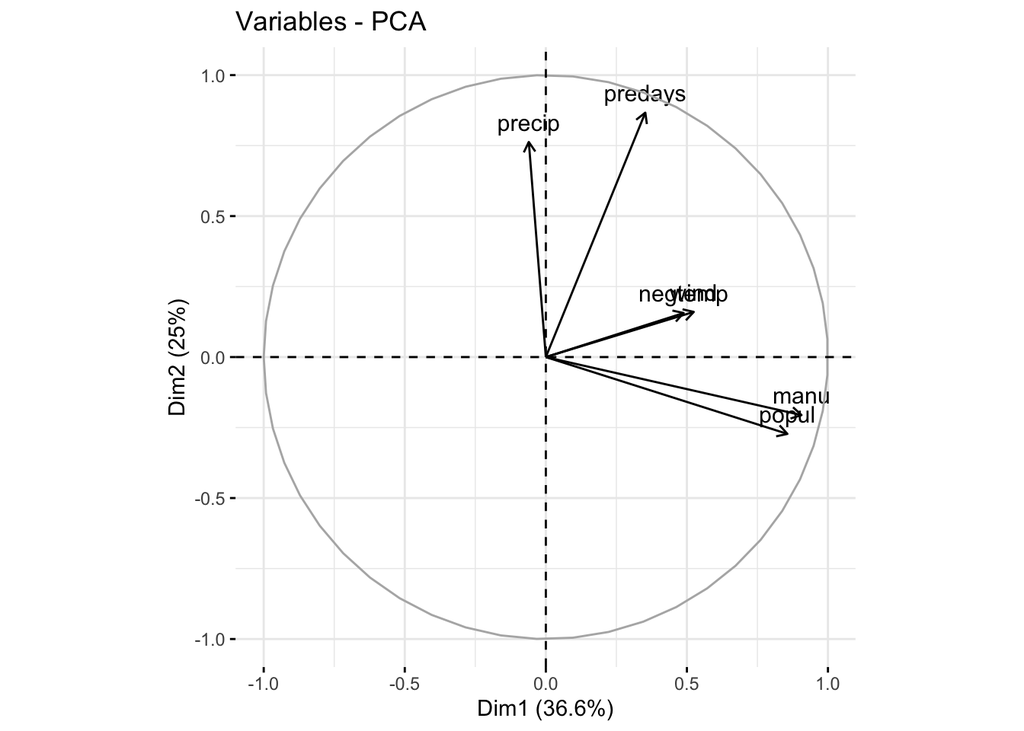

```r
fviz_pca_var(air.pca)
```

Another way to show arrows. A bit clearer.

```r
var = get_pca_var(air.pca)
var$coord
```

```
##               Dim.1      Dim.2      Dim.3       Dim.4       Dim.5        Dim.6
## manu     0.90627258 -0.2058239 -0.3222658  0.11931281  0.03453951 -0.130471152
## popul    0.85630067 -0.2724433 -0.4137753  0.06319713 -0.02642384  0.128925256
## wind     0.52436980  0.1601832  0.3510421 -0.75806100 -0.03833890 -0.004551836
## precip  -0.06047377  0.7628275 -0.5958649 -0.14922586  0.19232035  0.011251469
## predays  0.35257846  0.8668156  0.1099331  0.27143159 -0.19632137 -0.004075886
## negtemp  0.48851762  0.1562713  0.7932295  0.26720314  0.18889252  0.025276422
```

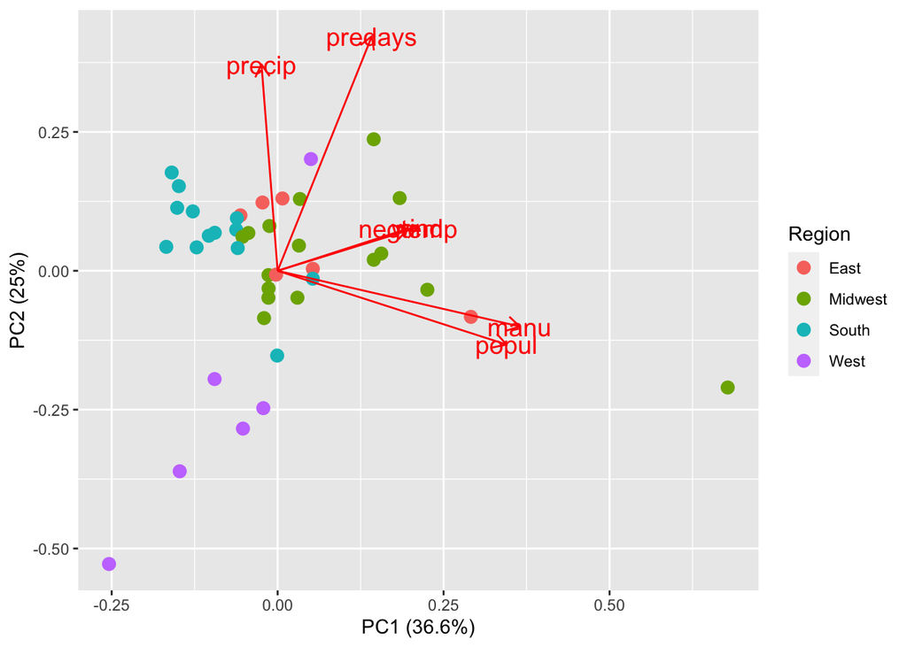

```r
autoplot(
  air.pca,
  data = air,
  colour = 'Region',
  loadings=TRUE,
  size = 3,
  loadings.label = TRUE,
  loadings.label.size=5
  )
```

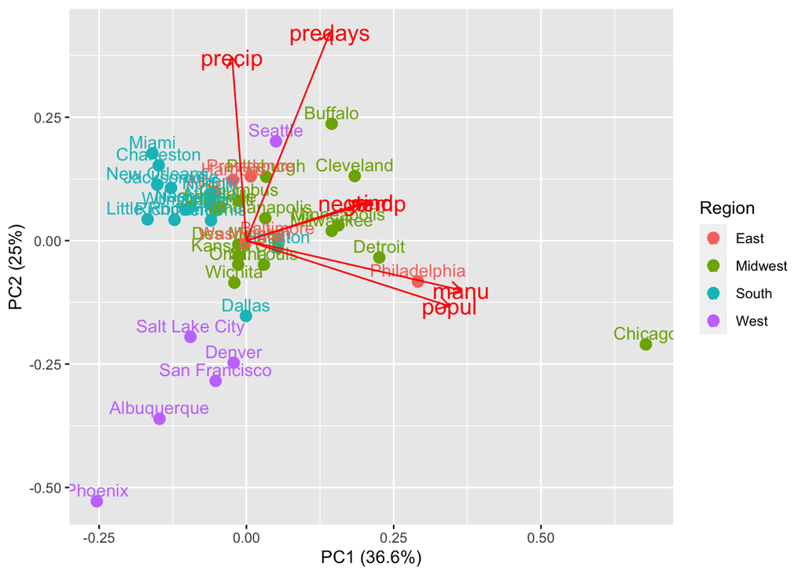

```r
autoplot(
  air.pca,
  data = air,
  colour = 'Region',
  loadings=TRUE,
  size = 3,
  loadings.label = TRUE,
  loadings.label.size=5,
  label=TRUE,
  label.label = 'City',
  label.vjust = -0.4
  )
```

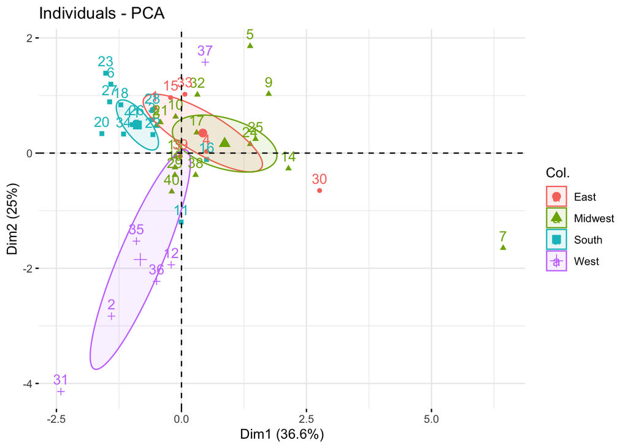

```r
fviz_pca_ind(
  air.pca,
  col.ind = air$Region,
  addEllipses = TRUE,
  mean.point = TRUE,
  ellipse.type = 'confidence'
  )
```

### Using PCA for a regression

```r
# set up the principal components
air.pca = prcomp(
  air[,c(-1,-8,-9)],
  center=TRUE,
  scale.=TRUE)

# get the values
scores = air.pca$x

# set up model (SO2 v. the PCA scores we calculated)
model = lm(SO2~scores, data = air)

summary(model)
```

```
##
## Call:
## lm(formula = SO2 ~ scores, data = air)
##
## Residuals:
##     Min      1Q  Median      3Q     Max
## -23.004  -8.542  -0.991   5.758  48.758
##
## Coefficients:
##             Estimate Std. Error t value Pr(>|t|)
## (Intercept)  30.0488     2.2858  13.146 6.91e-15 ***
## scoresPC1    10.0655     1.5616   6.446 2.28e-07 ***
## scoresPC2     2.2674     1.8895   1.200  0.23845
## scoresPC3    -0.3797     1.9596  -0.194  0.84752
## scoresPC4     8.6553     2.6541   3.261  0.00253 **
## scoresPC5    15.3644     6.8369   2.247  0.03122 *
## scoresPC6   -39.7591    12.4686  -3.189  0.00306 **
## ---
## Signif. codes:  0 '***' 0.001 '**' 0.01 '*' 0.05 '.' 0.1 ' ' 1
##
## Residual standard error: 14.64 on 34 degrees of freedom
## Multiple R-squared:  0.6695, Adjusted R-squared:  0.6112
## F-statistic: 11.48 on 6 and 34 DF,  p-value: 5.419e-07
```

### PCA example 2

```r
# Subset out only the species biomass data
pgd = pg[,1:54]

pg.pca = prcomp(pgd, scale=TRUE)
summary(pg.pca)
```

```
## Importance of components:
##                           PC1    PC2    PC3     PC4     PC5     PC6     PC7
## Standard deviation     3.0048 2.3358 1.9317 1.78562 1.73303 1.51187 1.50878
## Proportion of Variance 0.1672 0.1010 0.0691 0.05904 0.05562 0.04233 0.04216
## Cumulative Proportion  0.1672 0.2682 0.3373 0.39639 0.45201 0.49434 0.53649
##                            PC8     PC9    PC10    PC11    PC12    PC13    PC14
## Standard deviation     1.37586 1.32441 1.27318 1.21950 1.19792 1.17227 1.13551
## Proportion of Variance 0.03506 0.03248 0.03002 0.02754 0.02657 0.02545 0.02388
## Cumulative Proportion  0.57155 0.60403 0.63405 0.66159 0.68816 0.71361 0.73749
##                           PC15    PC16    PC17    PC18    PC19    PC20    PC21
## Standard deviation     1.09308 1.06783 1.00572 0.95504 0.91853 0.89466 0.86437
## Proportion of Variance 0.02213 0.02112 0.01873 0.01689 0.01562 0.01482 0.01384
## Cumulative Proportion  0.75961 0.78073 0.79946 0.81635 0.83198 0.84680 0.86063
##                           PC22    PC23    PC24    PC25    PC26    PC27    PC28
## Standard deviation     0.84970 0.76898 0.75135 0.74191 0.70653 0.69475 0.67325
## Proportion of Variance 0.01337 0.01095 0.01045 0.01019 0.00924 0.00894 0.00839
## Cumulative Proportion  0.87401 0.88496 0.89541 0.90560 0.91485 0.92379 0.93218
##                           PC29    PC30    PC31    PC32    PC33    PC34    PC35
## Standard deviation     0.62565 0.56800 0.56269 0.53857 0.52670 0.49524 0.48706
## Proportion of Variance 0.00725 0.00597 0.00586 0.00537 0.00514 0.00454 0.00439
## Cumulative Proportion  0.93943 0.94540 0.95127 0.95664 0.96177 0.96632 0.97071
##                           PC36    PC37   PC38    PC39    PC40    PC41    PC42
## Standard deviation     0.46638 0.44471 0.4025 0.37661 0.35794 0.34381 0.31452
## Proportion of Variance 0.00403 0.00366 0.0030 0.00263 0.00237 0.00219 0.00183
## Cumulative Proportion  0.97474 0.97840 0.9814 0.98403 0.98640 0.98859 0.99042
##                           PC43    PC44    PC45    PC46    PC47    PC48    PC49
## Standard deviation     0.29639 0.26849 0.25825 0.23467 0.22753 0.21756 0.19922
## Proportion of Variance 0.00163 0.00133 0.00124 0.00102 0.00096 0.00088 0.00073
## Cumulative Proportion  0.99205 0.99338 0.99462 0.99564 0.99660 0.99747 0.99821
##                           PC50    PC51    PC52    PC53    PC54
## Standard deviation     0.17755 0.16758 0.15581 0.11255 0.01721
## Proportion of Variance 0.00058 0.00052 0.00045 0.00023 0.00001
## Cumulative Proportion  0.99879 0.99931 0.99976 0.99999 1.00000
```

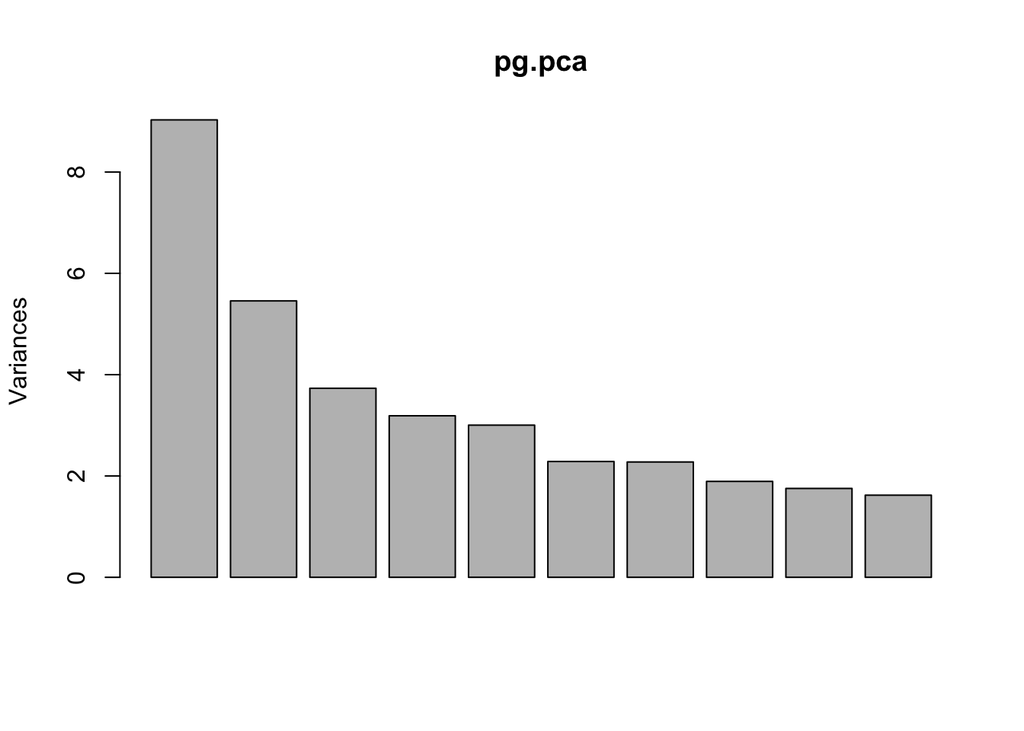

```r
screeplot(pg.pca)
```

When you have a lot of components, it doesn’t print them all

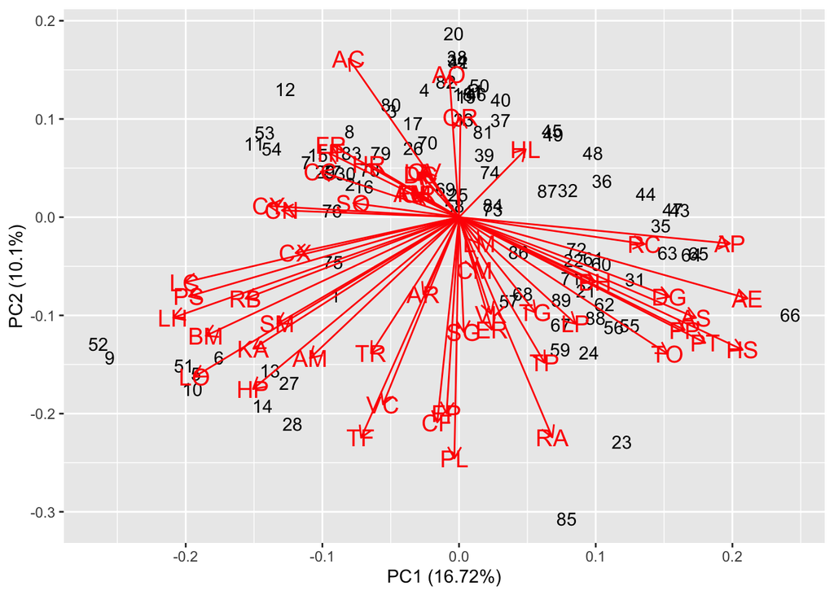

```r
autoplot(
  pg.pca,
  data = pgd,
  loadings=TRUE,
  size = 3,
  label=TRUE,
  alpha=0,
  loadings.label = TRUE,
  loadings.label.size=5)
```

### plotting components against the original predictor varaibles

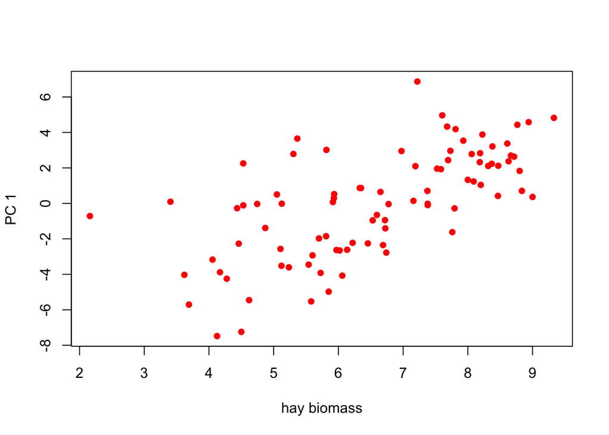

```r
yv <- predict(pg.pca)[,1] # PC1
plot(pg$hay,
     yv,
     pch=16,
     xlab="hay biomass",
     ylab="PC 1",
     col="red")
```

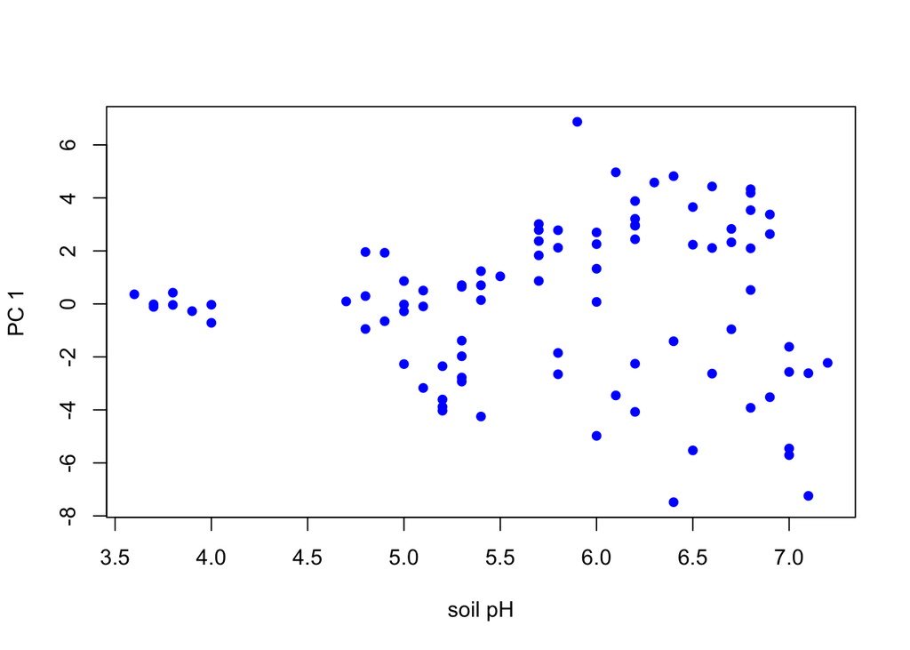

```r
yv1 <- predict(pg.pca)[,1] # PC1
plot(pg$pH,
     yv1,
     pch=16,
     xlab="soil pH",
     ylab="PC 1",
     col="blue")
```

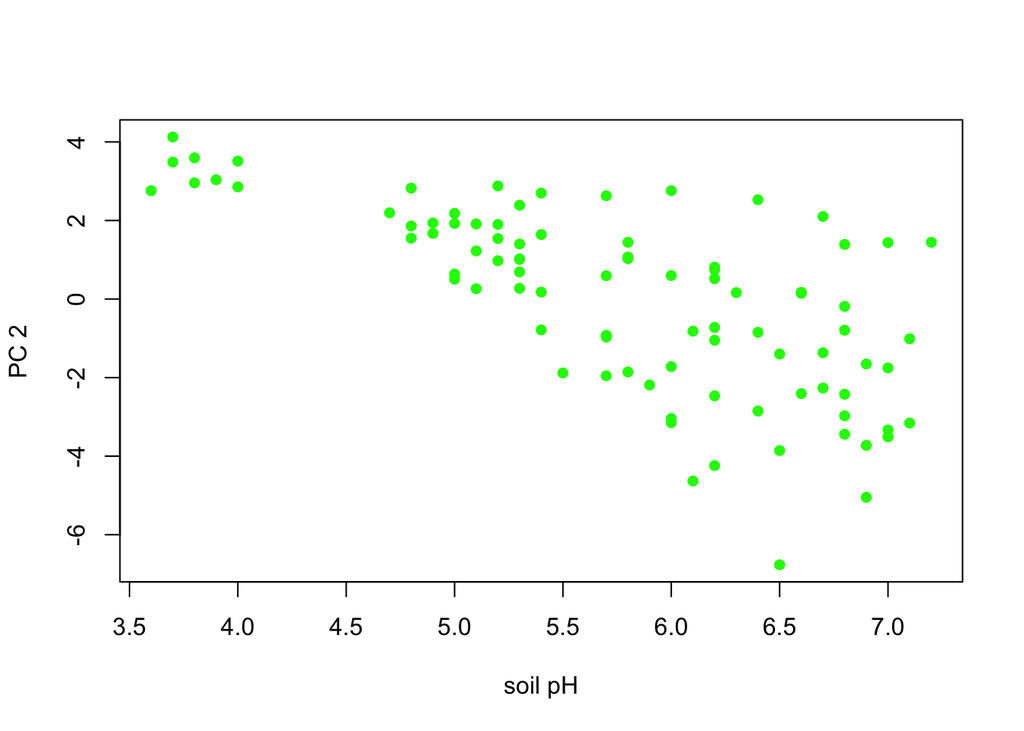

```r
yv2 <- predict(pg.pca)[,2] # PC2
plot(pg$pH,
     yv2,
     pch=16,
     xlab="soil pH",
     ylab="PC 2",
     col="green")
```

Correlation between hay biomass and PC1. No correlation between soil pH and PC1. Strong negative correlation between soil pH and PC2.

# Homework

Notes: - Write code to load the sparrow data - Treat column 1 (‘survive’ 0 or 1) as the response, don’t include it in the PCA1.

Problems: 1. Produce a pairs plot of the various bird traits 2. Fit a PCA, using centered and scaled trait data. Show the summary output for the PCA 3. Produce a scree plot 4. Produce a biplot using the ggfortify package autoplot() function, showing the birds colored by survival, and arrows showing the variables in the PCA. Make sure your Rmd file knits successfully (hit the Knit button at the top of the script window)

```r
sparrow = read.csv("bumpus.dat.txt", header=TRUE, sep="\t")
head(sparrow)
```

```
##   survive length alar weight  lbh  lhum  lfem ltibio wskull lkeel
## 1       1    154   41    4.5 31.0 0.687 0.668  1.000  0.587 0.830
## 2       0    165   40    6.5 31.0 0.738 0.704  1.095  0.606 0.847
## 3       0    160   45    6.1 30.0 0.736 0.709  1.109  0.611 0.840
## 4       1    160   50    6.9 30.8 0.736 0.709  1.180  0.600 0.841
## 5       1    155   43    6.9 30.6 0.733 0.704  1.151  0.600 0.846
## 6       0    161   49    5.6 30.3 0.743 0.718  1.108  0.600 0.808
```

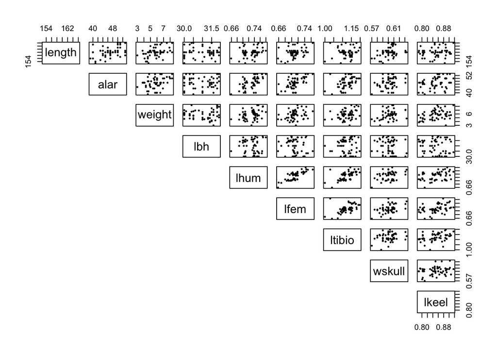

```r
# Produce a pairs plot of the various bird traits

pairs(sparrow[,c(-1)], cex = 0.5, pch = 20, lower.panel=NULL)
```

There’s pretty clear correlation between “lhum” and “lfem”, “lhum” and “ltbio”, and “lfem” and “ltbio”.

```r
# Fit a PCA, using centered and scaled trait data.
# Show the summary output for the PCA

sparrow.pca = prcomp(sparrow[,c(-1)], center=TRUE, scale=TRUE)
summary(sparrow.pca)
```

```
## Importance of components:
##                           PC1    PC2    PC3     PC4     PC5     PC6     PC7
## Standard deviation     1.9157 1.0714 1.0532 0.92150 0.77703 0.77225 0.64838
## Proportion of Variance 0.4078 0.1275 0.1232 0.09435 0.06709 0.06626 0.04671
## Cumulative Proportion  0.4078 0.5353 0.6586 0.75291 0.82000 0.88626 0.93297
##                            PC8     PC9
## Standard deviation     0.64262 0.43624
## Proportion of Variance 0.04589 0.02115
## Cumulative Proportion  0.97885 1.00000
```

75% of the variation is explained by the first 4 principal components. But principal component 1 explains a full 40.78% of the variance on it’s own.

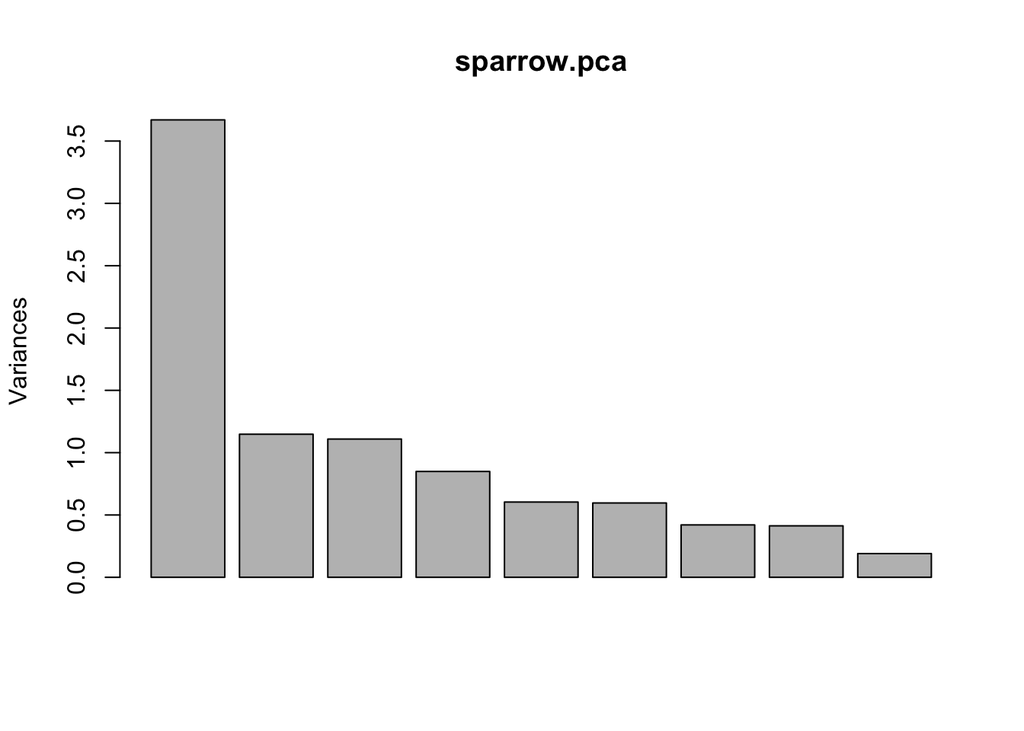

```r
# Produce a scree plot

screeplot(sparrow.pca)
```

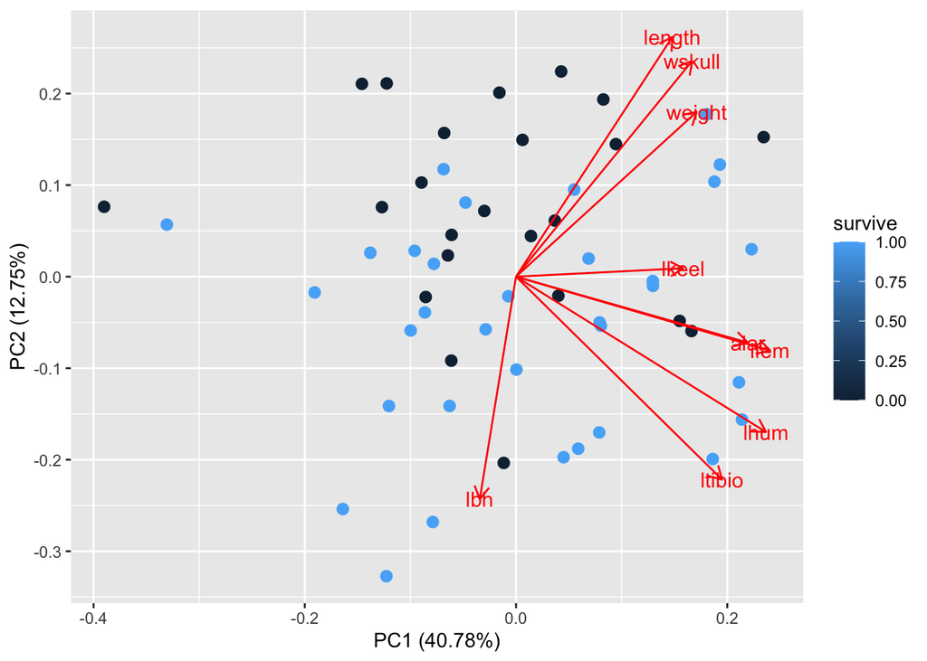

```r
# Produce a biplot using the ggfortify package autoplot() function, showing
# the birds colored by survival, and arrows showing the variables in the PCA.

autoplot(
  sparrow.pca,
  data = sparrow,
  colour = 'survive',
  loadings=TRUE,
  size = 4,
  shape = 20,
  loadings.label = TRUE,
  loadings.label.size=4,
)
```

Light blue is survived = 1, dark blue is survived = 0. lbh has the least contribution to PC1, while lkeel has the least contribution to PC2.